# Introducción a la Inferencia Bayesiana usando RStan

Ignacio Evangelista

27 de agosto de 2019

```r
library(rstan)
library(ggplot2)
library(bayesplot)
```

# Ejemplo 1: Caso Simple

## Binomial

Se hacen dos encuestas a $N$ personas de las cuales $Y$ responden a favor de cierto aspecto:

```r
N      <- c(20,100)
Y      <- c(4,70)
```

## ¿Cómo lo representamos en RStan?

Definimos el modelo

```r
model1_stan <- "
data {
  int<lower=1> n;
  int N[n];
  int Y[n];
}
parameters {
  real<lower=0, upper=1> theta;
}
model {
  theta ~ beta(2,2);
  Y ~ binomial(N, theta);
}"
```

Datos: `n` (número de datos), `N` (número de ensayos) e `Y` (número de aciertos)

Parámetros: `theta` (probabilidad de acierto)

Modelo: $Y_i \sim \mathcal{Bi}(N_i,\theta)$

Prior: $\theta \sim \beta(2,2)$

## Cuidado

- No olvidar el final de línea ;
- Todas las variables tienen que estar declaradas

Lo compilamos

```r
model1 <- stan_model(model_code = model1_stan)
```

Y preparamos los datos

```r
data_list <- list(Y=Y, N=N, n=length(Y))
```

Muestreamos nuestra cadena

```r
model1_fit <- sampling(object=model1,
                       data=data_list,
                       chains = 3,
                       iter = 1000,
                       warmup = 100)
```

3 cadenas con 1000 iteraciones cada una, de las cuales 100 son de *warm-up*

## Resultados

```r
model1_fit
```

```
## Inference for Stan model: b3b34ec2778f36fc4743d552664edb06.
## 3 chains, each with iter=1000; warmup=100; thin=1;
## post-warmup draws per chain=900, total post-warmup draws=2700.
##
##         mean se_mean   sd   2.5%    25%    50%    75%  97.5% n_eff Rhat
## theta   0.61    0.00 0.04   0.53   0.58   0.61   0.64   0.70  1105    1
## lp__  -83.26    0.02 0.69 -85.11 -83.44 -82.99 -82.82 -82.76  1509    1
##
## Samples were drawn using NUTS(diag_e) at Tue Aug 27 22:54:50 2019.
## For each parameter, n_eff is a crude measure of effective sample size,
## and Rhat is the potential scale reduction factor on split chains (at
## convergence, Rhat=1).
```

Podemos usar la función `summary`

```r
summary(model1_fit)
```

```
## $summary
##              mean    se_mean         sd        2.5%         25%
## theta   0.6134775 0.00130227 0.04329277   0.5308372   0.5841742
## lp__  -83.2580981 0.01776698 0.69020974 -85.1106978 -83.4423432
##               50%         75%       97.5%    n_eff     Rhat
## theta   0.6136959   0.6449218   0.6951914 1105.169 1.000996
## lp__  -82.9941080 -82.8168972 -82.7621639 1509.159 1.000167
##
## $c_summary
## , , chains = chain:1
##
##          stats
## parameter        mean         sd        2.5%         25%         50%
##     theta   0.6119047 0.04420983   0.5294488   0.5809523   0.6113942
##     lp__  -83.2786698 0.73871918 -85.2064328 -83.4429734 -83.0194521
##          stats
## parameter         75%       97.5%
##     theta   0.6436733   0.6941749
##     lp__  -82.8176583 -82.7621251
##
## , , chains = chain:2
##
##          stats
## parameter        mean        sd        2.5%         25%         50%
##     theta   0.6143182 0.0423664   0.5364126   0.5855793   0.6142334
##     lp__  -83.2383131 0.6596142 -84.9818134 -83.4140255 -82.9880387
##          stats
## parameter         75%       97.5%
##     theta   0.6448781   0.6958614
##     lp__  -82.8165476 -82.7620888
##
## , , chains = chain:3
##
##          stats
## parameter        mean         sd        2.5%         25%        50%
##     theta   0.6142095 0.04328764   0.5303633   0.5859707   0.615753
##     lp__  -83.2573115 0.66978742 -85.1877596 -83.4485817 -82.984816
##          stats
## parameter         75%       97.5%
##     theta   0.6460948   0.6934537
##     lp__  -82.8165415 -82.7622912
```

¡Es mucha información!

¿Qué sacamos de un `summary`?

```r
str(summary(model1_fit))
```

```
## List of 2
##  $ summary  : num [1:2, 1:10] 0.6135 -83.2581 0.0013 0.0178 0.0433 ...
##   ..- attr(*, "dimnames")=List of 2
##   .. ..$ : chr [1:2] "theta" "lp__"
##   .. ..$ : chr [1:10] "mean" "se_mean" "sd" "2.5%" ...
##  $ c_summary: num [1:2, 1:7, 1:3] 0.6119 -83.2787 0.0442 0.7387 0.5294 ...
##   ..- attr(*, "dimnames")=List of 3
##   .. ..$ parameter: chr [1:2] "theta" "lp__"
##   .. ..$ stats    : chr [1:7] "mean" "sd" "2.5%" "25%" ...
##   .. ..$ chains   : chr [1:3] "chain:1" "chain:2" "chain:3"
```

```r
summary(model1_fit)$summary
```

```
##              mean    se_mean         sd        2.5%         25%
## theta   0.6134775 0.00130227 0.04329277   0.5308372   0.5841742
## lp__  -83.2580981 0.01776698 0.69020974 -85.1106978 -83.4423432
##               50%         75%       97.5%    n_eff     Rhat
## theta   0.6136959   0.6449218   0.6951914 1105.169 1.000996
## lp__  -82.9941080 -82.8168972 -82.7621639 1509.159 1.000167
```

¿Podemos operar con el *posterior*?

Como una **lista**

```r
list_of_draws <- extract(model1_fit,pars="theta")
str(list_of_draws)
```

```
## List of 1
##  $ theta: num [1:2700(1d)] 0.602 0.565 0.541 0.636 0.655 ...
##   ..- attr(*, "dimnames")=List of 1
##   .. ..$ iterations: NULL
```

```r
dim(list_of_draws$theta)
```

```
## [1] 2700
```

¿Por qué esa dimensión? `chains*(iter-warmup)`

```r
head(list_of_draws$theta)
```

```
## [1] 0.6020146 0.5647697 0.5413286 0.6359584 0.6548393 0.5415340
```

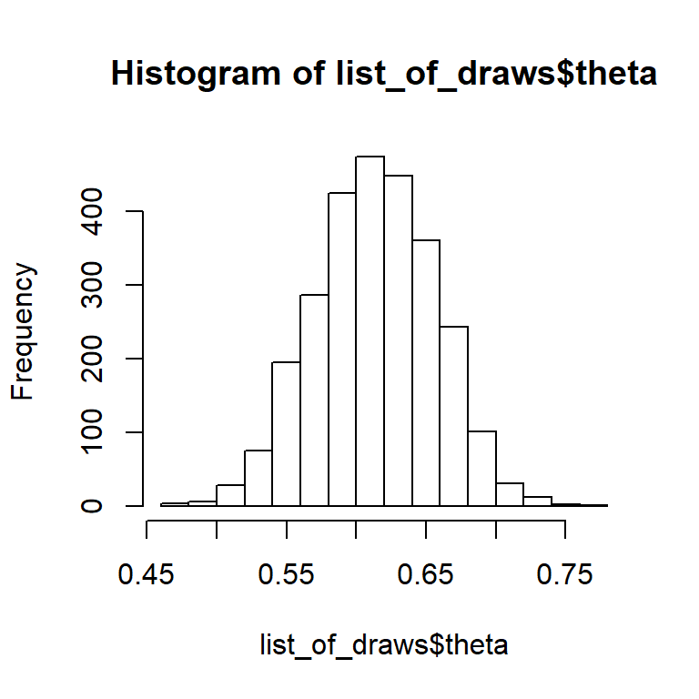

```r
hist(list_of_draws$theta)
```

¿Cuál es la **probabilidad** de que la proporción de éxito sea menor que 0.5?

```r
mean(list_of_draws$theta<0.5)
```

```
## [1] 0.004074074
```

Como un **dataframe**

```r
df_of_draws <- as.data.frame(model1_fit,pars="theta")
head(df_of_draws)
```

```
##       theta
## 1 0.5819092
## 2 0.6836855
## 3 0.6861654
## 4 0.6648942
## 5 0.6136606
## 6 0.6230467
```

Como una **matriz**

```r
matrix_of_draws <- as.matrix(model1_fit,pars="theta")
```

Es bastante cómodo para trabajar con otros paquetes…

Como un **array**

```r
array_of_draws <- as.array(model1_fit,pars="theta")
```

Esta variante conserva las cadenas en la segunda dimensión

```r
str(array_of_draws)
```

```
##  num [1:900, 1:3, 1] 0.582 0.684 0.686 0.665 0.614 ...
##  - attr(*, "dimnames")=List of 3
##   ..$ iterations: NULL
##   ..$ chains    : chr [1:3] "chain:1" "chain:2" "chain:3"
##   ..$ parameters: chr "theta"
```

Así, para acceder a las muestras de la segunda cadena para el parámetro `theta`, hacemos:

```r
head(array_of_draws[,2,"theta"])
```

```
## [1] 0.6497571 0.5225679 0.6022103 0.6096552 0.5884623 0.6176518
```

## Ver el Posterior

Usando el paquete `bayesplot`

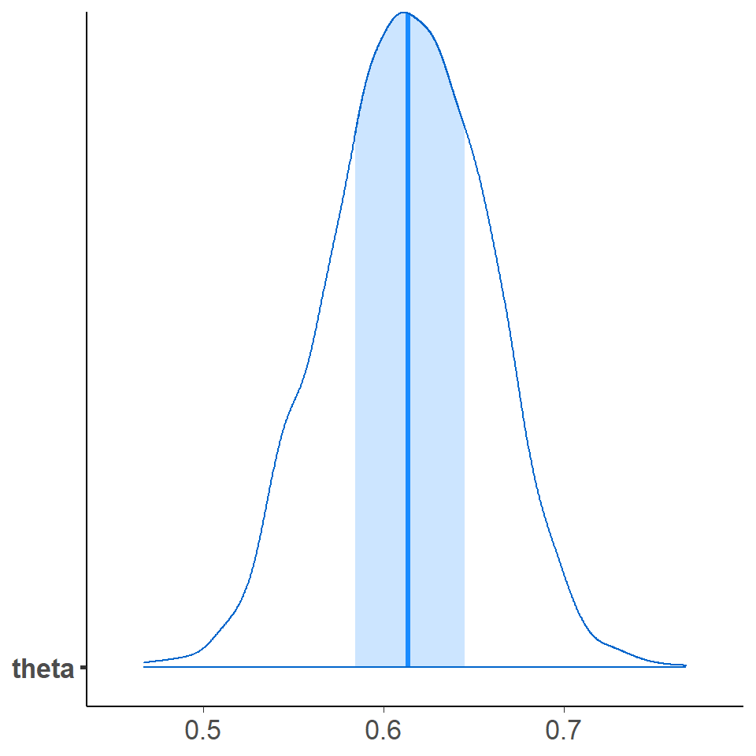

```r
bayesplot::mcmc_areas(array_of_draws,pars="theta")
```

Ver las cadenas…

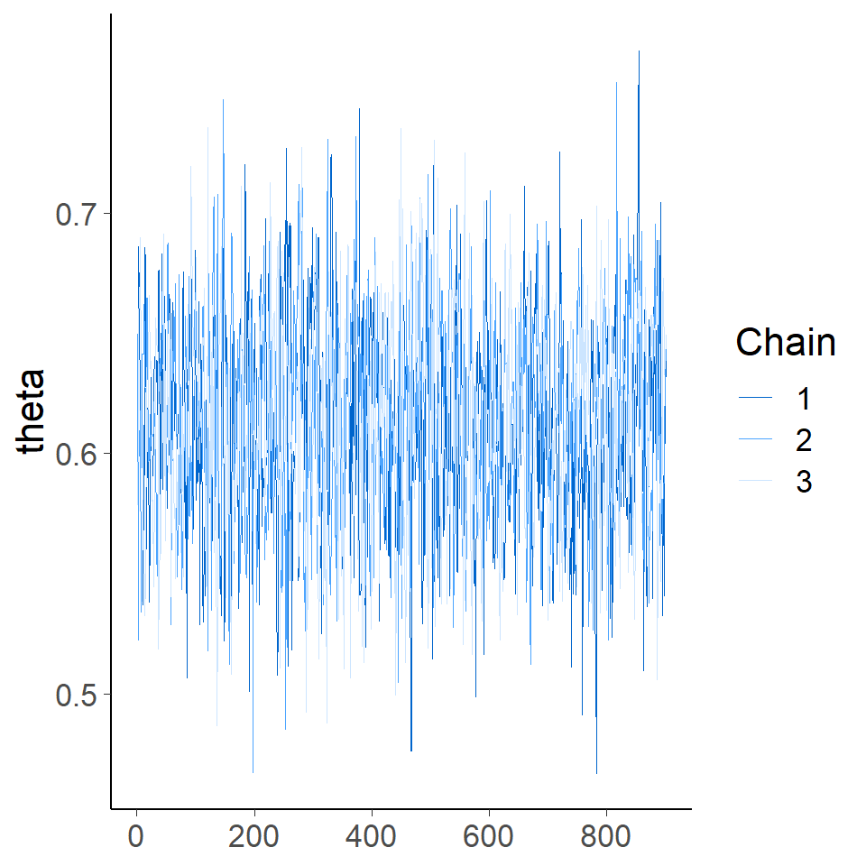

```r
bayesplot::mcmc_trace(array_of_draws,pars="theta")
```

¿Qué es eso?

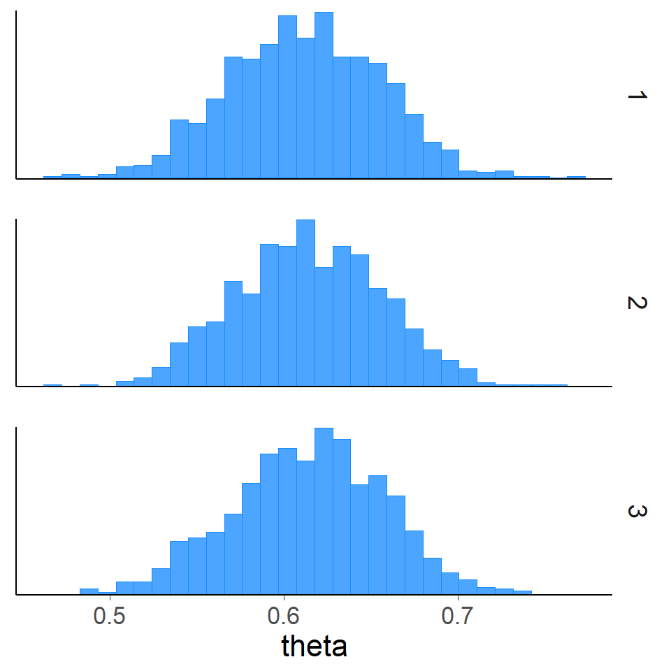

```r
bayesplot::mcmc_hist_by_chain(array_of_draws,pars="theta")
```

# Ejemplo 2: Regresión Lineal

## Datos de juguete

```r
x <- rnorm(100, 10, 1)
y <- 3*x+2
y <- y + rnorm(length(y),0,1)
data <- data.frame(x=x,y=y)
```

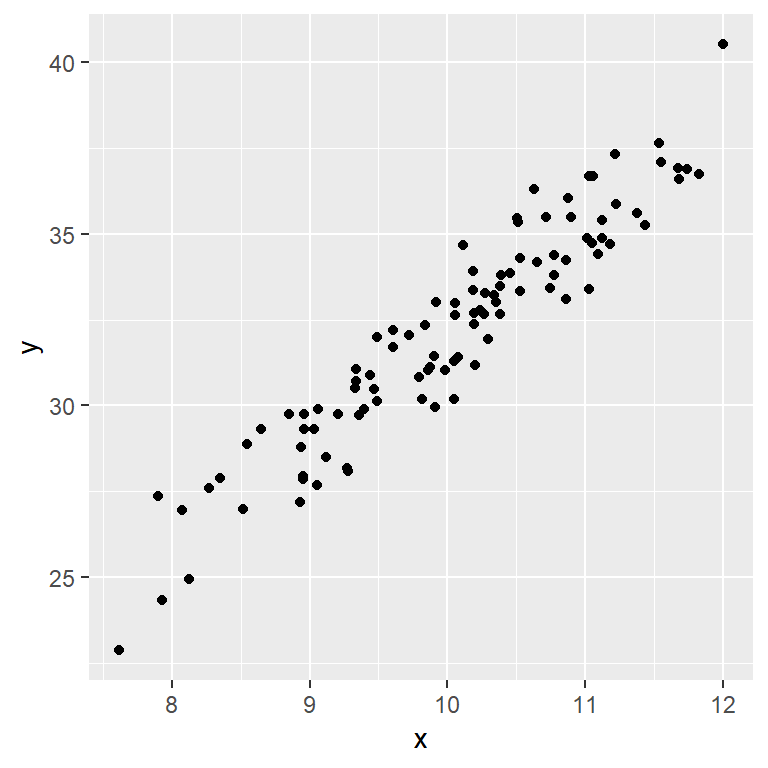

## Generalidades del modelo

El modelo que definimos es:
$$y_i \sim \mathcal{N}(\mu_i,\sigma)$$

con
$$\mu_i = \beta_0 + \beta_1 x_i$$

Se denominan *priors* no informativos o *non-commital*. Son más apropiados para Stan que un *prior* uniforme.

## Modelo 1

```r
model2_stan <- "
data {
  int<lower=0> N;
  vector[N] y;
  vector[N] x;
}
parameters {
  real beta0;
  real beta1;
  real<lower=0> sigma;
}
model {
  beta0 ~ normal(0,10);
  beta1 ~ normal(0,10);
  sigma ~ normal(0,20);
  y ~ normal(beta0 + beta1*x,sigma);
}"
```

En el ejemplo anterior habíamos definido `int y[N]`, es análogo a `vector[N] y`

Lo compilamos

```r
model2 <- stan_model(model_code = model2_stan)
```

Y preparamos los datos

```r
data_list <- list(x=x, y=y, N=length(y))
```

```r
model2_fit <- sampling(object=model2,
                       data=data_list,
                       chains = 1,
                       iter = 8000,
                       warmup = 1000)
summary(model2_fit,pars=c("beta0","beta1","sigma"))$summary
```

```
##           mean     se_mean         sd       2.5%       25%      50%
## beta0 1.110382 0.023930550 1.12251355 -1.0567375 0.3578139 1.095554
## beta1 3.096708 0.002377413 0.11160546  2.8761654 3.0216044 3.097901
## sigma 1.074559 0.001485661 0.07755835  0.9364968 1.0199087 1.068832
##            75%    97.5%    n_eff     Rhat
## beta0 1.864855 3.379049 2200.279 1.000211
## beta1 3.171613 3.312219 2203.746 1.000180
## sigma 1.124299 1.237316 2725.320 1.000915
```

Atención al `n_eff` (en breve…)

Comparar con el `lm` de R

```r
lm(y~x)
```

```
##
## Call:
## lm(formula = y ~ x)
##
## Coefficients:
## (Intercept)            x
##       1.107        3.097
```

## Diagnósticos

```r
model2_samples<-as.matrix(model2_fit,pars=c("beta0","beta1","sigma"))
```

Los intervalos de credibilidad para los parámetros se ven correctos…

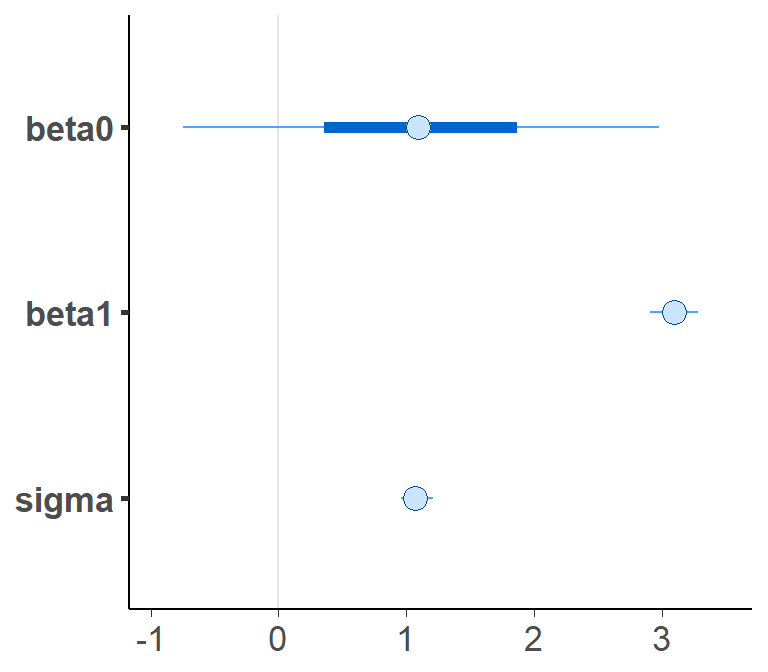

```r
bayesplot::mcmc_intervals(model2_samples)
```

No obstante, hay que tener precaución…

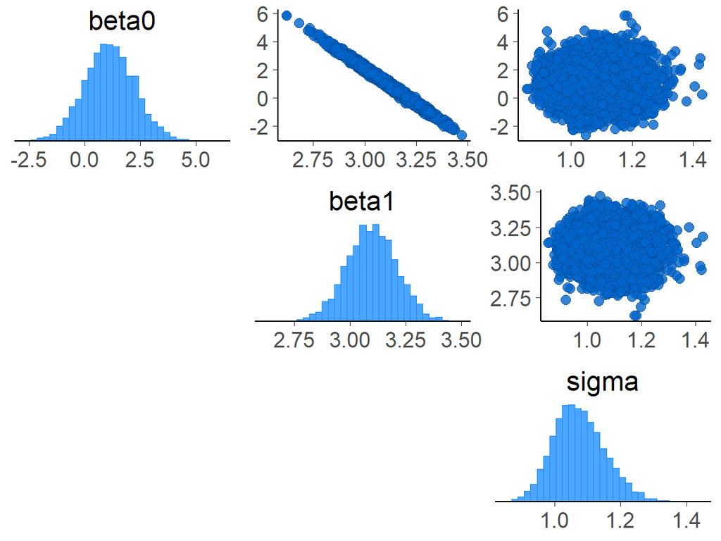

```r
bayesplot::mcmc_pairs(model2_samples)
```

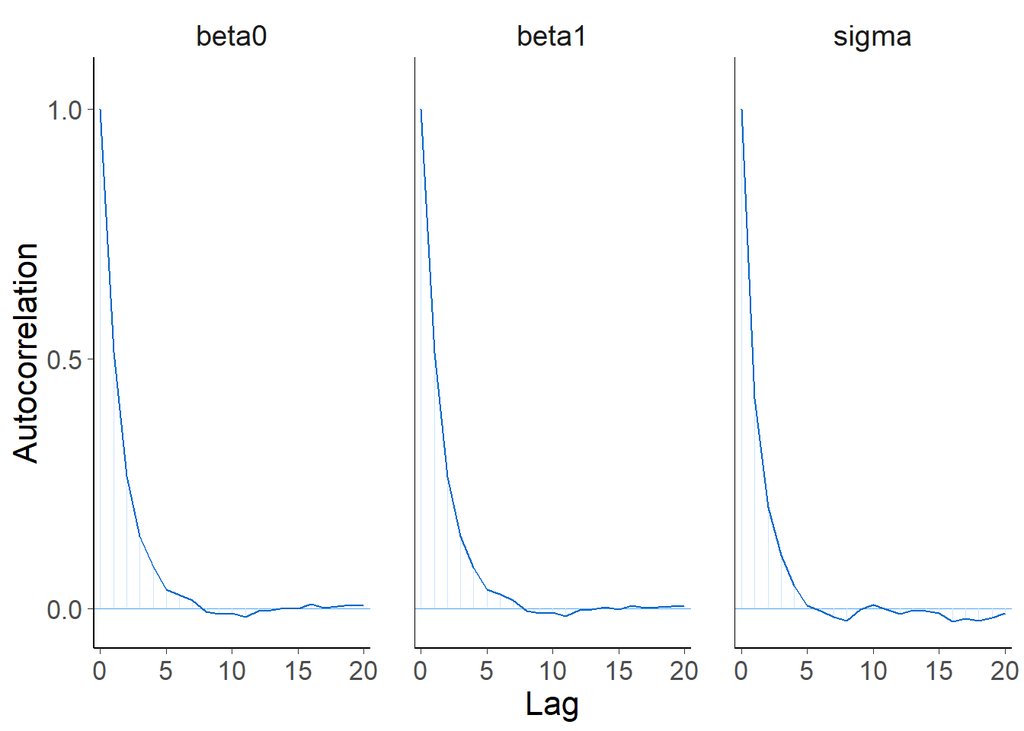

```r
bayesplot::mcmc_acf(model2_samples)
```

## Modelo 2

Transformamos los datos para estandarizar `x` en `x_std` en el bloque `transformed data`

```r
model3_stan <- "
data {
  int<lower=0> N;
  vector[N] y;
  vector[N] x;
}
transformed data {
  vector[N] x_std;
  x_std = (x - mean(x)) / sd(x);
}
parameters {
  real beta0;
  real beta1;
  real<lower=0> sigma;
}
model {
  beta0 ~ normal(0,10);
  beta1 ~ normal(0,10);
  sigma ~ normal(0,20);
  y ~ normal(beta0 + beta1*x_std,sigma);
}
generated quantities { // para cada muestra de la cadena!
  real beta1_orig;
  real beta0_orig;
  beta1_orig = beta1 / sd(x);
  beta0_orig = beta0 - beta1 * mean(x) / sd(x);
}"
```

Usamos el bloque `generated quantities` para obtener el parámetro original. Los cálculos se hacen una vez por iteración de la cadena.

```r
model3 <- stan_model(model_code = model3_stan)
```

```r
model3_fit <- sampling(object=model3,
                       data=data_list,
                       chains = 1,
                       iter = 8000,
                       warmup = 1000)
```

Las `generated quantities` también son una cadena y podemos agregarlas al `summary`

```r
summary(model3_fit,pars=c("beta0","beta1","sigma",
                          "beta1_orig","beta0_orig"))$summary
```

```
##                 mean     se_mean         sd       2.5%        25%
## beta0      32.151188 0.001120344 0.10858423 31.9418897 32.0786502
## beta1       3.066141 0.001368161 0.10915734  2.8523752  2.9933454
## sigma       1.073097 0.001054933 0.07690732  0.9378073  1.0196437
## beta1_orig  3.098164 0.001382450 0.11029739  2.8821656  3.0246082
## beta0_orig  1.090644 0.013908213 1.11203966 -1.0821923  0.3528733
##                  50%       75%     97.5%    n_eff      Rhat
## beta0      32.149891 32.224041 32.365599 9393.574 0.9998913
## beta1       3.065943  3.138753  3.280486 6365.487 0.9999540
## sigma       1.068198  1.122656  1.235682 5314.789 1.0000141
## beta1_orig  3.097964  3.171535  3.314748 6365.487 0.9999540
## beta0_orig  1.081204  1.837631  3.285798 6392.900 0.9999420
```

```r
model3_samples<-as.matrix(model3_fit,
                    pars=c("beta0","beta1","sigma",
                           "beta1_orig","beta0_orig"))
```

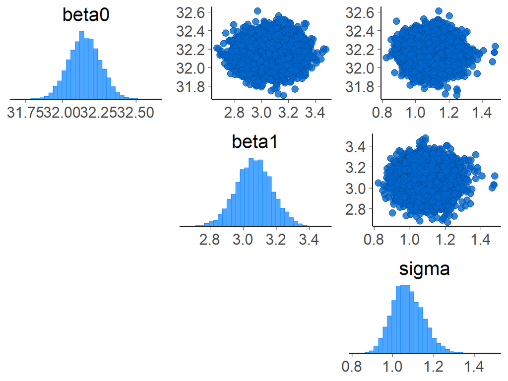

```r
bayesplot::mcmc_pairs(model3_samples,pars=c("beta0","beta1","sigma"))
```

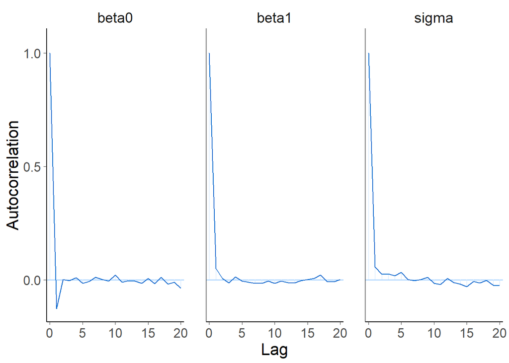

```r
bayesplot::mcmc_acf(model3_samples,pars=c("beta0","beta1","sigma"))
```

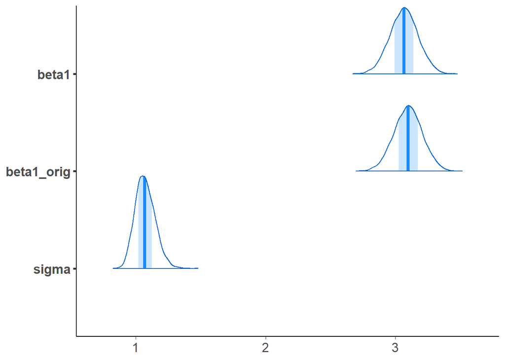

```r
bayesplot::mcmc_areas(model3_samples,pars=c("beta1","beta1_orig","sigma"))
```

## Posterior Predictive Checks (PPC)

> Simular datos bajo el modelo ajustado y compararlos con los datos observados, con el objetivo de buscar discrepancias sistemáticas

Utilizando el bloque `generated_quantities` vamos a realizar replicaciones de las predicciones del modelo: `y_rep[i]` para cada `x[i]` Una para cadena

**Incorporamos la incertidumbre en los parámetros**

```r
"generated quantities { // para cada muestra de la cadena!
  real beta1_orig;
  real beta0_orig
  vector[N] y_rep;
  beta1_orig = beta1 / sd(x);
  beta0_orig = beta0 - beta1 * mean(x) / sd(x);
  for(n in 1:N) {
  y_rep[n] = normal_rng(beta0 + beta1_orig * x[n], sigma);
  }"
```

## Modelo 3

```r
model4_stan <- "
data {
  int<lower=0> N;
  vector[N] y;
  vector[N] x;
}
transformed data {
  vector[N] x_std;
  x_std = (x - mean(x)) / sd(x);
}
parameters {
  real beta0;
  real beta1;
  real<lower=0> sigma;
}
model {
  beta0 ~ normal(0,10);
  beta1 ~ normal(0,10);
  sigma ~ normal(0,20);
  y ~ normal(beta0 + beta1*x_std,sigma);
}
  generated quantities { // para cada muestra de la cadena!
  real beta1_orig;
  real beta0_orig;
  vector[N] y_rep;
  beta1_orig = beta1 / sd(x);
  beta0_orig = beta0 - beta1 * mean(x) / sd(x);
  for(n in 1:N) {
  y_rep[n] = normal_rng(beta0_orig + beta1_orig * x[n], sigma);
  }
}
"
```

```r
model4_samples <- as.matrix(model4_fit,
                            pars=c("beta0","beta1","sigma",
                                   "beta1_orig","beta0_orig"))
```

```r
model4_y_rep <- as.matrix(model4_fit,pars="y_rep")
```

Usamos solo 100 elementos de nuestra cadena para un chequeo gráfico

```r
i <- sample(1:3900,100)
```

Usamos la función `ppc_intervals` del paquete `bayesplot` que recibe como argumento los `N` datos observados, y una matriz de `i` repeticiones (filas) de los `N` datos (columnas)

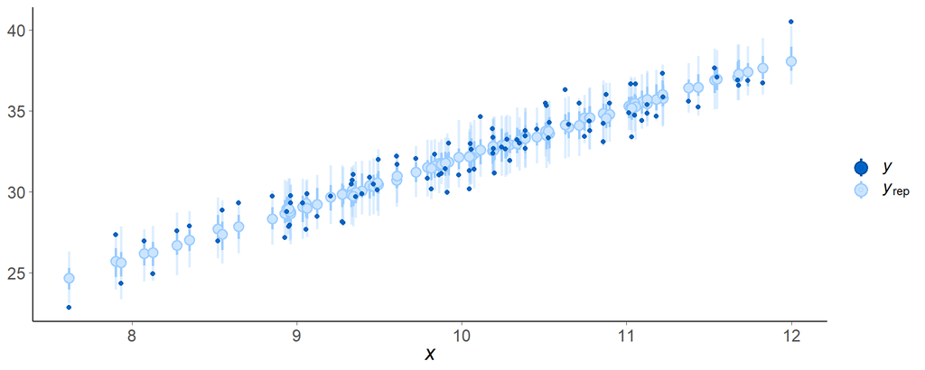

```r
bayesplot::ppc_intervals(y=y,yrep=model4_y_rep[i,],x=x)
```

Probar también la función `ppc_ribbons`

¿Se pueden ver las rectas de regresión? Sí, para ello podemos usar el paquete `ggplot2`, para lo cual necesitamos dataframes

```r
model4_samples <- as.data.frame(model4_samples)
```

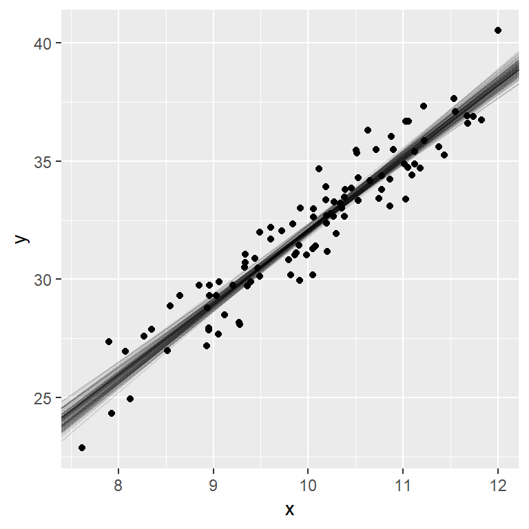

```r
ggplot() + geom_point(data=data,aes(x=x,y=y)) +
  geom_abline(data=model4_samples[i,],
              aes(slope = beta1_orig,
                  intercept=beta0_orig),
              alpha=0.1)
```

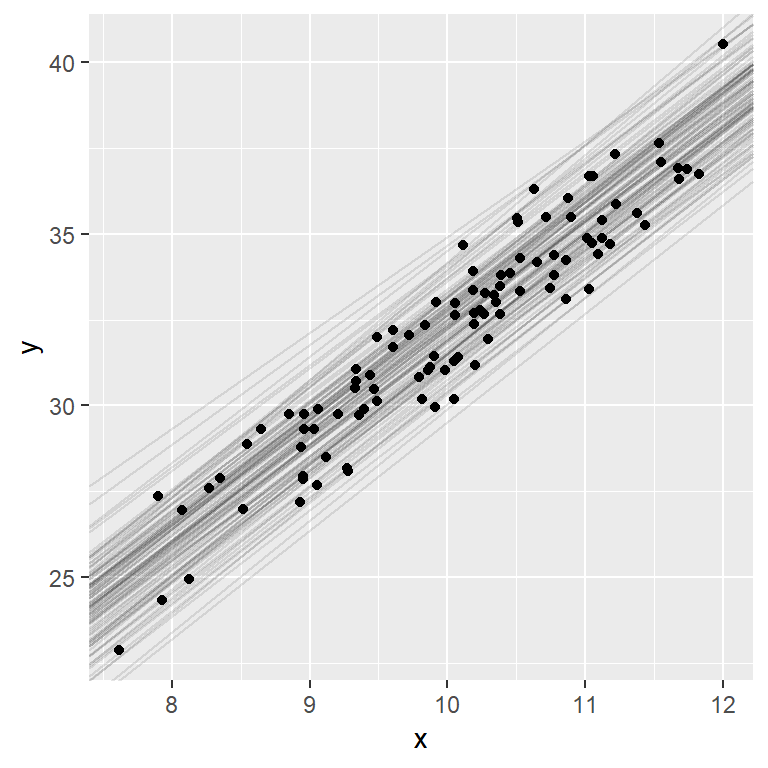

```r
ggplot() + geom_point(data=data,aes(x=x,y=y)) +
  geom_abline(data=model4_samples[i,],
              aes(slope = beta1_orig,
                  intercept=beta0_orig+rnorm(n=100,mean=0,sd=sigma)),
              alpha=0.1)
```

# Ejemplo 3: t-test

## Datos de juguete

```r
n1 <- 36
n2 <- 30
Ntotal <- n1 + n2
y1 <- rnorm(n1,1.1,0.3)
y2 <- rnorm(n2,0.7,0.6)
y<-c(y1,y2)
group_id<-c(rep(1,n1),rep(2,n2))
```

## Generalidades del modelo<sup>$\star$</sup>

<sup>$\star$</sup> *Basado en: Kruschke, J. 2013. Bayesian Estimation Supersedes the t Test. Journal of Experimental Psychology: General. 142(2).*

El modelo que definimos es:
$$y_{ji} \sim \mathcal{t}(\nu+1,\mu_j,\sigma_j)$$

con
$$j = 1,2$$

Asumiremos los siguientes priors:
$$\mu_j \sim \mathcal{N}\left(\tilde{\mu}_{\mbox{prior}},\tilde{\sigma}_{\mbox{prior}}\right)$$
$$\sigma_j \sim \mathcal{N}(0,20)$$
$$\nu \sim \mathcal{Exp}\left(\frac{1}{29}\right)$$
(Un prior que balancea distribuciones casi normales $\nu\to\infty$ con distribuciones de colas pesadas $\nu<30$)

## Modelo 5

```r
"data {
  int n1;
  int n2;
  int N;
  vector[N] y;
  int group_id[N];
  real mu_prior_location;
  real mu_prior_scale;
}
parameters {
  real mu[2];
  real<lower=0, upper=1000> sigma[2];
  real<lower=0, upper=1000> nu;
}
model {
  mu ~ normal(mu_prior_location, mu_prior_scale);
  sigma ~ normal(0, 20);
  nu ~ exponential(1.0/29.0);
  y ~ student_t(nu, mu[group_id],sigma[group_id]);
}"
```

```r
"generated quantities {
  real diff_mu;
  vector[n1] y1_rep;
  vector[n2] y2_rep;

  diff_mu = mu[1] - mu[2];

  for(n in 1:n1) {
  y1_rep[n] = student_t_rng(nu,mu[1],sigma[1]);
  }

  for(n in 1:n2) {
  y2_rep[n] = student_t_rng(nu,mu[2],sigma[2]);
  }
}"
```

```r
model5 <- stan_model(model_code = model5_stan)
```

```r
data_list <- list(group_id=group_id,
                  y=y,
                  n1=n1,
                  n2=n2,
                  N=Ntotal,
                  mu_prior_location=(mean(y1)+mean(y2))/2,
                  mu_prior_scale=max(sd(y1),sd(y2))*1000)
```

```r
model5_fit <- sampling(object=model5,
                       data=data_list,
                       chains = 4,
                       iter = 4000,
                       warmup = 100)
```

```r
fit5_summary <- summary(model5_fit,
                        pars=c("mu","sigma","nu","diff_mu"))$summary
```

```r
model5_samples<-as.matrix(model5_fit,
                          pars=c("mu","sigma","nu","diff_mu"))
```

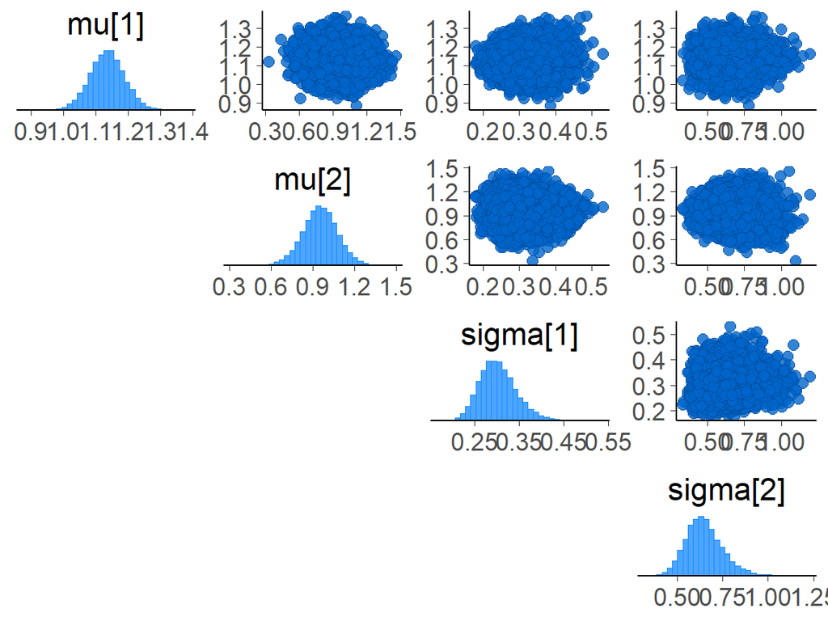

```r
bayesplot::mcmc_pairs(model5_samples,
                      c("mu[1]","mu[2]","sigma[1]","sigma[2]"))
```

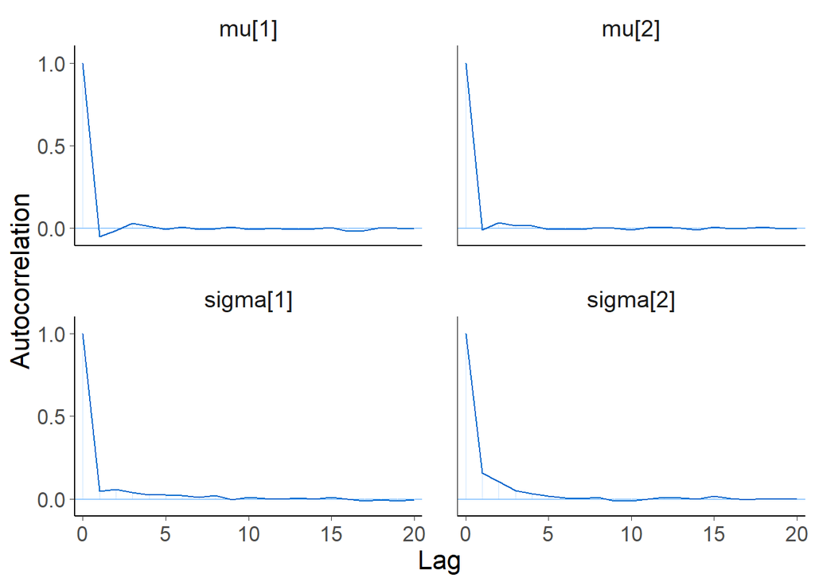

```r
bayesplot::mcmc_acf(model5_samples,
                    c("mu[1]","mu[2]","sigma[1]","sigma[2]"))
```

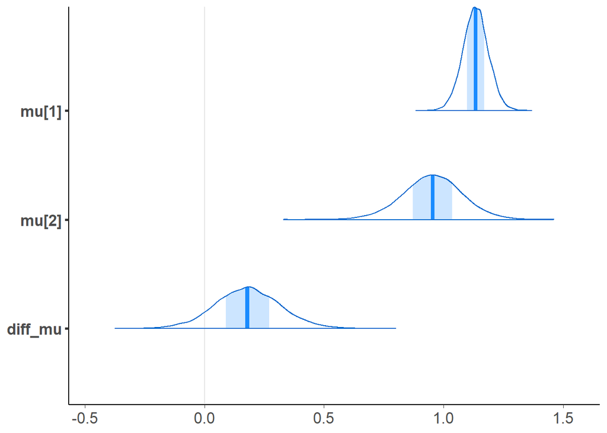

```r
mcmc_areas(model5_samples,pars=c("mu[1]","mu[2]","diff_mu"))
```

```r
mean(model5_samples[,"diff_mu"]>0)
```

```
## [1] 0.9109615
```

Es posible definir una ROPE (*region of practical equivalence*), de forma tal que la inferencia pueda apoyar la hipótesis nula

Posterior predictive checks

```r
model5_y1_rep <- as.matrix(model5_fit,pars="y1_rep")
model5_y2_rep <- as.matrix(model5_fit,pars="y2_rep")
i <- sample(1:15600,size = 100)
```

¿Qué tan bien ajusta nuestro modelo a los datos observados?

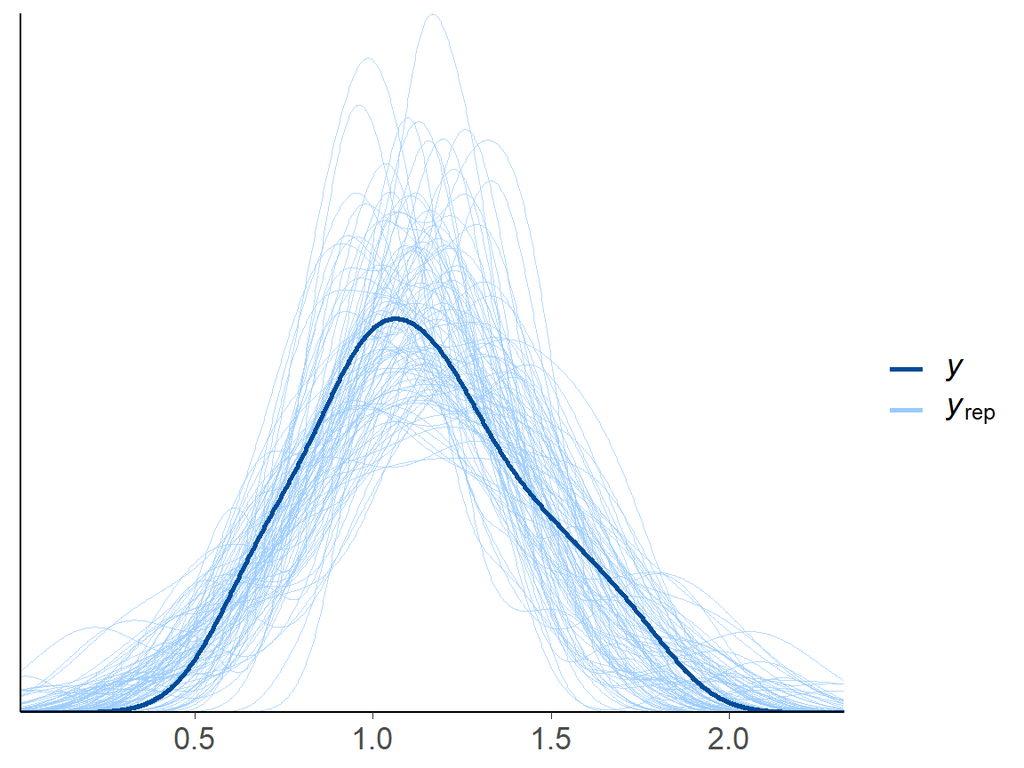

```r
ppc_dens_overlay(y1,model5_y1_rep[i,])
```

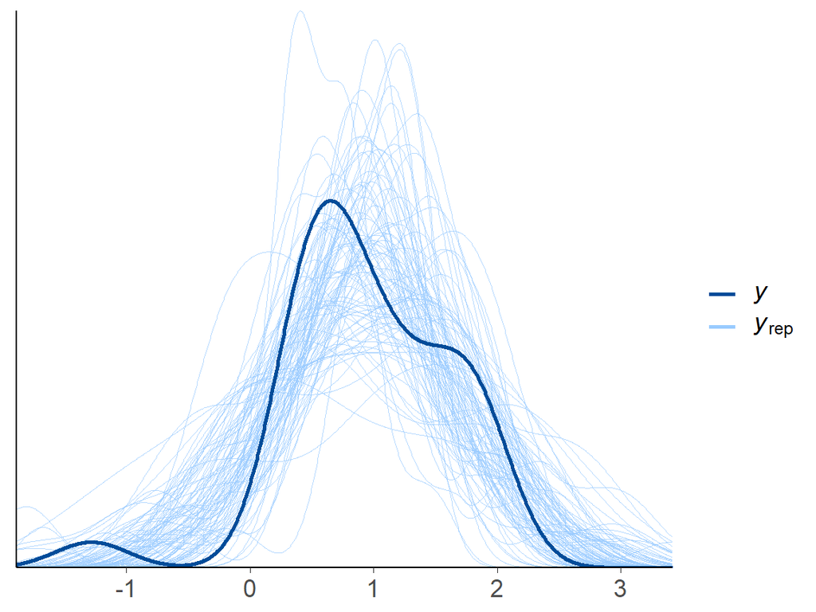

```r
ppc_dens_overlay(y2,model5_y2_rep[i,])
```